# 4. Mixed Membership Models

Edoardo Cortolezzis

2025-01-14

# Excercise 4: Mixed membership models

**Consider a subset of the data of end-of-year addresses of the presidents of the Italian Republic (in the course Team files) from 1992 (beginning of Scalfaro office) to 2021 (end of Mattarella first office). Select nouns, adjectives and verbs with a frequency of at least 5 occurrences as textual units of analysis. Fit a topic model by opportunely choosing the model structure – whether and how incorporating metadata (President and speech year) for detecting any significant influence on topic structure, and number of topics. Comment on the results and provide an effective visualization to help understanding.**

## Data loading, cleaning and preprocessing

### Data loading

Loading the data and displaying an overview: from 1992 (beginning of Scalfaro) to 2021 (end of Mattarella):

```r
pathtofile <- "datasets/Corpus EndofYear/Corpus EoY lemm/"

pres_dat <- readtext(paste0(pathtofile, "*.txt"), encoding = "UTF-8")

# Filter to include only the last 30 speeches: from SCALFARO_1992 to MATTARELLA_2021
pres_dat <- pres_dat %>% tail(30)

# Extracting metadata: year and president
pres_dat <- pres_dat %>%
  mutate(
    year = as.integer(str_extract(doc_id, "\\d{4}")),  # Extracts four consecutive digits as the year
    pres = str_extract(doc_id, "[A-Z]+")  # Extracts consecutive uppercase letters as the president's name
    )

# Display an overview
print(pres_dat, n = 30)
```

```
## readtext object consisting of 30 documents and 2 docvars.
## # A data frame: 30 × 4
##    doc_id                      text                  year pres
##  * <chr>                       <chr>                <int> <chr>
##  1 44_SCALFARO_1992_I.txt      "\"\nbuono_A s\"..."  1992 SCALFARO
##  2 45_SCALFARO_1993_II.txt     "\"\nbuono_A s\"..."  1993 SCALFARO
##  3 46_SCALFARO_1994_III.txt    "\"\nbuono_A s\"..."  1994 SCALFARO
##  4 47_SCALFARO_1995_IV.txt     "\"\nbuono_A s\"..."  1995 SCALFARO
##  5 48_SCALFARO_1996_V.txt      "\"\nbuono_A s\"..."  1996 SCALFARO
##  6 49_SCALFARO_1997_VI.txt     "\"\nbuono_A s\"..."  1997 SCALFARO
##  7 50_SCALFARO_1998_VII.txt    "\"\nbuono_A s\"..."  1998 SCALFARO
##  8 51_CIAMPI_1999_I.txt        "\"\nitaliano_\"..."  1999 CIAMPI
##  9 52_CIAMPI_2000_II.txt       "\"\nitaliano_\"..."  2000 CIAMPI
## 10 53_CIAMPI_2001_III.txt      "\"\ncaro_A it\"..."  2001 CIAMPI
## 11 54_CIAMPI_2002_IV.txt       "\"\ncaro_A it\"..."  2002 CIAMPI
```

[output cut: 19 more lines]

Before filtering words, let’s take a look at the texts we’ll be dealing with:

- Corpus and vocabulary sizes:

```
## No. word-tokens: 69738
```

```
## No. word-types: 5269
```

- Example of text:

```
##  buono_A sera_N a_PREP tutto_A! buon_A anno_N! essere_V il_DET augurio_N, il_DET primo_A mio_A augurio_N; mi_PRON emozionare_V in_PREP presentare_V, quasi_AVV lo_PRON
```

There is some preprocessing that needs to be done before fitting the topic model. We will keep nouns (_N and _NM), adjectives (_A) and verbs (_V) with a frequency of at least 5 occurrences as textual units of analysis.

### Data cleaning

Fisrt, let’s remove extra characters and POS tags:

```r
# filtering on POS tags:
pres_dat$text <- pres_dat$text %>%
    gsub("\n", " ", .) %>%
    noquote %>%
    str_replace_all(., "[,;.:()?!°'%«»-]", " ") %>% # Remove punctuation
    # filtering out POS tags:
    # with a blank space before the POS tag
    gsub(" \\w+_CONG", "", .) %>%
    gsub(" \\w+_DET", "", .) %>%
    gsub(" \\w+_PREP", "", .) %>%
    gsub(" \\w+_AVV", "", .) %>%
    gsub(" \\w+_NUM", "", .) %>%
    gsub(" \\w+_PRON", "", .) %>%
    gsub(" \\w+_ESC", "", .) %>%
    gsub(" \\w+_O ", " ", .) %>%
    # without a blank space before the POS tag
    gsub("\\w+_CONG", "", .) %>%
    gsub("\\w+_DET", "", .) %>%
    gsub("\\w+_PREP", "", .) %>%
    gsub(" \\w+_AVV", "", .) %>%
    gsub(" \\w+_NUM", "", .) %>%
    gsub("\\w+_PRON", "", .) %>%
    gsub(" \\w+_ESC", "", .) %>%
    gsub("\\w+_O ", " ", .)


# removing POS tags:
pres_dat$text <- pres_dat$text %>%
    gsub("_NM", "", .) %>%
    gsub("_N", "", .) %>%
    gsub("_A", "", .) %>%
    gsub("_V", "", .)
```

```
## Same example as before, but after POS filtering and having removed the POS tags:
##   buono sera tutto buon anno essere augurio primo mio augurio emozionare presentare vedere partire giungere tutto accogliere bontà essere
```

Then, let’s remove the words with less than 5 occurrences:

```r
# Tokenization and word count with filtering
tidy_pres <- pres_dat %>%
  unnest_tokens(word, text) %>%
  count(word, sort = TRUE) %>%
  filter(n > 4) # Keep only words with a frequency of at least 5

# Print the filtered data
cat("Most freequent words:\n")
```

```
## Most freequent words:
```

```r
head(tidy_pres)
```

```
## readtext object consisting of 6 documents and 0 docvars.
## # A data frame: 6 × 3
##   word       n text
## * <chr>  <int> <chr>
## 1 essere  2178 "\"\"..."
## 2 avere   1095 "\"\"..."
## 3 questo   507 "\"\"..."
## 4 nostro   465 "\"\"..."
## 5 italia   371 "\"\"..."
## 6 potere   362 "\"\"..."
```

```r
cat("\nLess freequent words:\n")
```

```
##
## Less freequent words:
```

```r
tail(tidy_pres)
```

```
## readtext object consisting of 6 documents and 0 docvars.
## # A data frame: 6 × 3
##   word          n text
## * <chr>     <int> <chr>
## 1 turbare       5 "\"\"..."
## 2 urna          5 "\"\"..."
## 3 uso           5 "\"\"..."
## 4 vaccinare     5 "\"\"..."
## 5 vista         5 "\"\"..."
## 6 vittoria      5 "\"\"..."
```

```
## After filtering:
## No. word-tokens: 32232
## No. word-types: 1296
```

It’s evident that the most frequent words are “essere” and “avere”, however, we can avoid considering them in the analysis, since they would not provide any meaningful information.

```r
# Remove specific words ("essere" and "avere") from the text data
pres_dat$text <- pres_dat$text %>%
  str_replace_all("\\bessere\\b|\\bavere\\b", "")

# Tokenization and word count with filtering
tidy_pres <- pres_dat %>%
  unnest_tokens(word, text) %>%
  count(word, sort = TRUE) %>%
  filter(n > 4)

# Print the filtered data
print("Most freequent words:")
```

```
## [1] "Most freequent words:"
```

```r
head(tidy_pres)
```

```
## readtext object consisting of 6 documents and 0 docvars.
## # A data frame: 6 × 3
##   word       n text
## * <chr>  <int> <chr>
## 1 questo   507 "\"\"..."
## 2 nostro   465 "\"\"..."
## 3 italia   371 "\"\"..."
## 4 potere   362 "\"\"..."
## 5 fare     348 "\"\"..."
## 6 dovere   347 "\"\"..."
```

```
##
## After removing essere e avere:
## No. word-tokens: 28959
## No. word-types: 1294
```

Then, we could also take a look at the most frequent words per president:

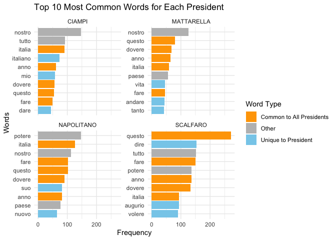

It seems like there are a lot of commonly used words among the presidents speeches, so this will probably be reflected in our analysis.

### Data preprocessing

Now we can process the text data using the `textProcessor` function, this prepare the data for later topic models.

```
## Building corpus...
## Removing custom punctuation...
## Removing numbers...
## Creating Output...
```

```
## Removing 2006 of 4536 terms (2006 of 18515 tokens) due to frequency
## Your corpus now has 30 documents, 2530 terms and 16509 tokens.
```

Alternatively, we can also preprocess the data with `dfm`. This data preparation will be useful in finding the ideal topic number with `FindTopicsNumber`.

```
## Document-feature matrix of: 6 documents, 4,545 features (83.89% sparse) and 2 docvars.
##                           features
## docs                       buono sera tutto buon anno augurio primo mio
##   44_SCALFARO_1992_I.txt       4    1    21    9   15      17     2   9
##   45_SCALFARO_1993_II.txt      3    2    22   11   24       7     5   4
##   46_SCALFARO_1994_III.txt     4    5    27    3    9      16     2   2
##   47_SCALFARO_1995_IV.txt      6    1    27    4   23      22     4   3
##   48_SCALFARO_1996_V.txt       2    3    19    5   14       9     0   2
##   49_SCALFARO_1997_VI.txt      1    2    19    3   26      16     3  11
##                           features
## docs                       emozionare presentare
##   44_SCALFARO_1992_I.txt            1          2
##   45_SCALFARO_1993_II.txt           0          2
##   46_SCALFARO_1994_III.txt          0          3
##   47_SCALFARO_1995_IV.txt           0          5
##   48_SCALFARO_1996_V.txt            1          1
##   49_SCALFARO_1997_VI.txt           0          1
## [ reached max_nfeat ... 4,535 more features ]
```

```
## [1]   30 4545
```

```
## [1] 34466
```

```
## [1] "documents" "vocab"     "meta"
```

```
## [1] 4545
```

Now the data is ready to be used by the models.

## Model fitting

### Ideal number of topics

Before fitting the models, we need to decide how many topics to consider in the analysis. For this task, we will use `searchK` and `FindTopicsNumber`.

- searchK: we’ll do 2 runs without metadata and 2 runs with metadata (president and year) to see if the inclusion of metadata affects the number of topics ideal for the models.

```r
k_search <- 2:50  # Tests from 2 to 50 topics

#without metadata:
#k1
start_time <- Sys.time() # Start timing
kResult_1 <- searchK(out$documents,
                     out$vocab,
                     K = k_search,
                     verbose = F,
                     heldout.seed = 2138)
end_time <- Sys.time()
k_1_time = end_time - start_time
cat("The 1st k search took:", k_1_time, "seconds\n")
save(kResult_1, file = "k_r1.Rdata")

#k2
start_time <- Sys.time() # Start timing
kResult_2 <- searchK(out$documents,
                     out$vocab,
                     K = k_search,
                     verbose = F,
                     heldout.seed = 83120)
end_time <- Sys.time()
k_2_time = end_time - start_time
cat("The 2nd k search took:", k_2_time, "seconds\n")
save(kResult_2, file = "k_r2.Rdata")


# with metadata:
#k3
start_time <- Sys.time() # Start timing
kResult_3 <- searchK(out$documents,
                     out$vocab,
                     K = k_search,
                     prevalence = ~ year, # non mi fa fare s(year)
                     content = ~ pres,
                     verbose = F,
                     heldout.seed = 2138,
                     data = meta)
end_time <- Sys.time()
k_3_time = end_time - start_time
cat("The 3rd k search took:", k_3_time, "seconds\n")
save(kResult_3, file = "k_r3.Rdata")



#k4
start_time <- Sys.time() # Start timing
kResult_4 <- searchK(out$documents,
                     out$vocab,
                     K = k_search,
                     prevalence = ~ year, # non mi fa fare s(year)
                     content = ~ pres,
                     verbose = F,
                     heldout.seed = 83120,
                     data = meta)
end_time <- Sys.time()
k_4_time = end_time - start_time
cat("The 4th k search took:", k_4_time, "seconds\n")
save(kResult_4, file = "k_r4.Rdata")
```

- Plottings without metadata:

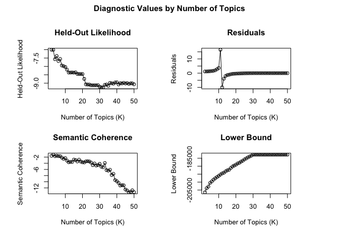

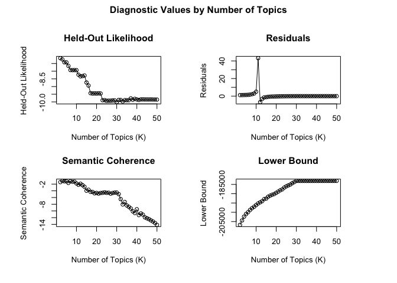

From these plots, we can see that the number of topics should be between 7 and 10.

- Plottings with metadata:

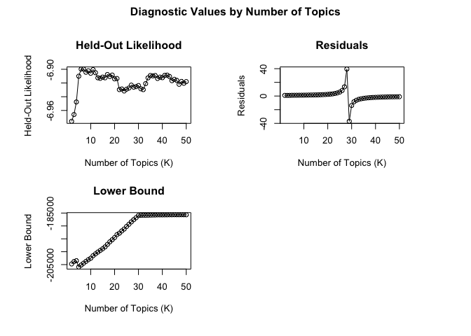

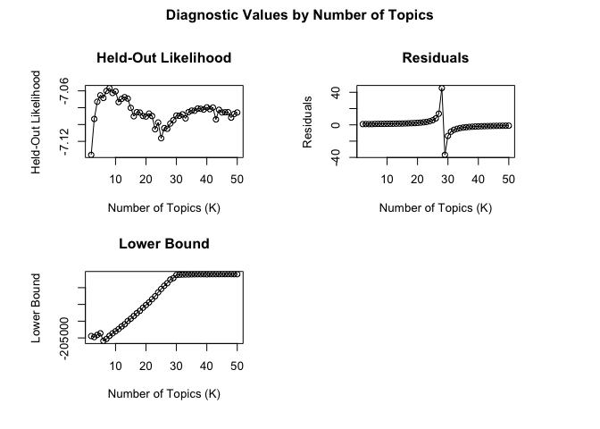

Again, from these other plots, we can see that the number of topics should be between 7 and 10. However, there seems to be some potential for a number of topics between 35 and 40.

Let’s see the plots from `FindTopicsNumber`, and decide which number of topics to consider.

- with FindTopicsNumber:

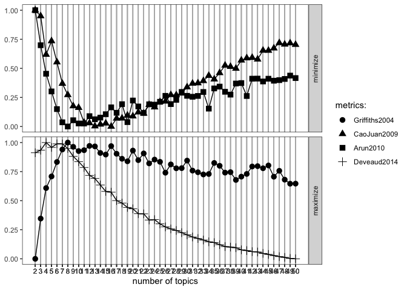

```r
result <- FindTopicsNumber(
    dati_dfm,
    topics = seq(from = 2, to = 50, by = 1),
    metrics = c("Griffiths2004", "CaoJuan2009", "Arun2010", "Deveaud2014"),
    method = "Gibbs",
    control = list(seed = 02138),
    mc.cores = 3L,  # Adjust based on your system capability
    verbose = TRUE
)
save(result, file = "k_ldatuning.Rdata")
```

It looks like, overall, 8 might be a good number of topics to consider.

### Without covariates

As a first model, we’ll fit a STM without covariates and with 8 topics:

- with spectral initialization:

```r
Fit0_spectral <- stm(out$documents,
            out$vocab,
            K = 8,
            data = out$meta,
            init.type = "Spectral",
            max.em.its = 500,
            seed = 2138,
            verbose = F)

save(Fit0_spectral, file = "stm_0.RData")
```

- with the `selectModel` function:

```r
Fit0_select <- selectModel(out$documents, out$vocab, K = 8, data = out$meta, max.em.its = 500, verbose = TRUE,
    init.type = "LDA", runs = 20, seed = 2138)

save(Fit0_select, file = "stm_0_select.RData")
```

After fitting the candidate models, we’ll choose one based on the semantic coherence and exclusivity metrics:

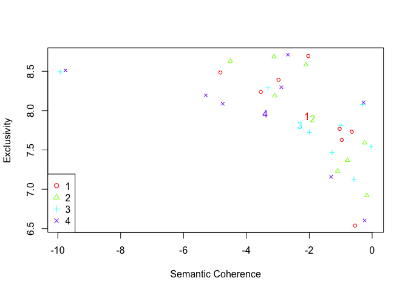

```
##
## Model 1 :
## Exclusivity: 7.933993
## Semantic Coherence: -2.071115
##
## Model 2 :
## Exclusivity: 7.899699
## Semantic Coherence: -1.89107
##
## Model 3 :
## Exclusivity: 7.816816
## Semantic Coherence: -2.301313
##
## Model 4 :
## Exclusivity: 7.958379
## Semantic Coherence: -3.397508
```

From these performances we can see that model 1 and 2 look like 2 good candidates. Let’s choose the first one and compare it with the one fitted by the spectral inizialization:

```r
Fit0_selectedmodel <- Fit0_select$runout[[1]]
```

Let’s compare it with the one fitted by the spectral inizialization:

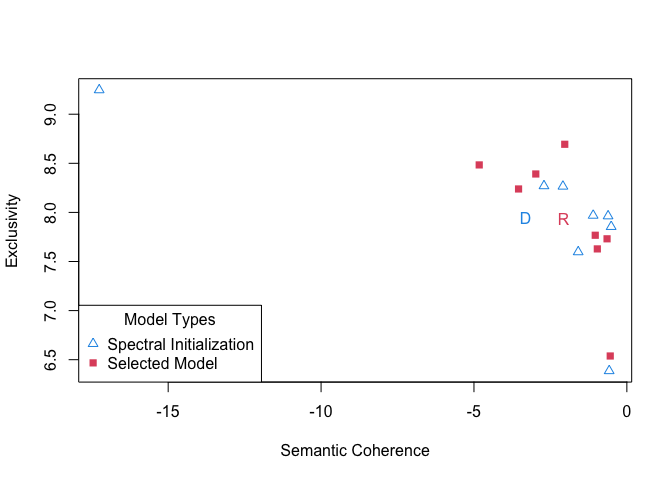

```
## Spectral Initialization Model:
```

```
## Exclusivity: 7.944154
```

```
## Semantic Coherence: -3.306455
```

```
##
##
## Selected Model:
```

```
## Exclusivity: 7.933993
```

```
## Semantic Coherence: -2.071115
```

The Exclusivity is similar, but the Semantic Coherence is higher for the selected model. Hence, we’ll choose the selected model as the best one without covariates.

### With covariates

For the model fitting with covariates we’ll try two different approaches:

```r
Fit_prevalence <- stm(out$documents,
                      out$vocab,
                      K = 8,
                      prevalence = ~ year + pres,
                      data = out$meta,
                      init.type = "Spectral",
                      max.em.its = 500,
                      seed = 2138,
                      verbose = FALSE)

Fit_prevalence_36 <- stm(out$documents,
                      out$vocab,
                      K = 36,
                      prevalence = ~ year + pres,
                      data = out$meta,
                      init.type = "Spectral",
                      max.em.its = 500,
                      seed = 2138,
                      verbose = FALSE)
```

[figure not shown]

```
## 8 topics model:
```

```
## Exclusivity: 7.917404
```

```
## Semantic Coherence: -3.338722
```

```
##
##
## 36 topics model:
```

```
## Exclusivity: 9.004029
```

```
## Semantic Coherence: -8.088916
```

Even though the Exclusivity is a little higher for the 36 topics model, the Semantic Coherence is too low compared to the 8 topics model. Hence, we’ll use 8 as number of topics.

#### pres as a Content Covariate

```r
Fit_content <- stm(documents = out$documents,
                   vocab = out$vocab,
                   K = 8,
                   prevalence = ~ year,
                   content = ~ pres,
                   data = out$meta,
                   init.type = "Spectral",
                   max.em.its = 500,
                   seed = 2138,
                   verbose = FALSE)
```

## Model evaluation and Results

### Topic shares within the documents

- Fit0_selectedmodel:

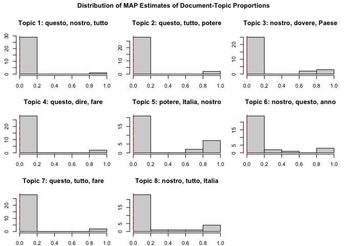

- Fit_prevalence:

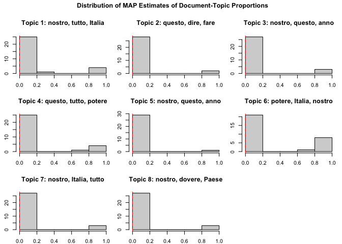

- Fit_content:

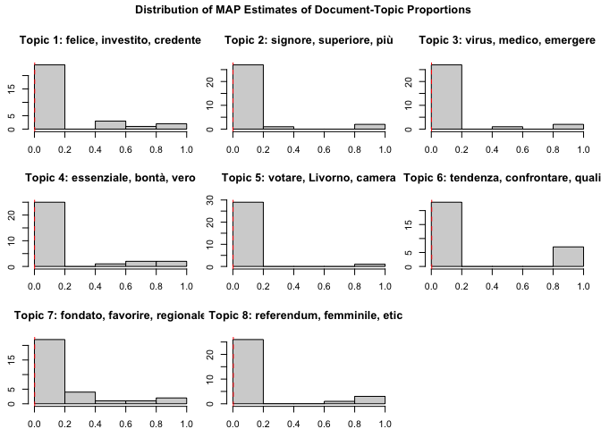

Most topics have document-topic proportions concentrated near 0. This indicates that each document is typically associated with only a few dominant topics, which is a sign of well-fitted topic models for many real-world corpora.

Furthermore, the presence of low document-topic proportions for most topics suggests the topics are distinct and not overlapping too much. This means that the model successfully identifies different thematic clusters.

### Topic correlation

- Fit0_selectedmodel:

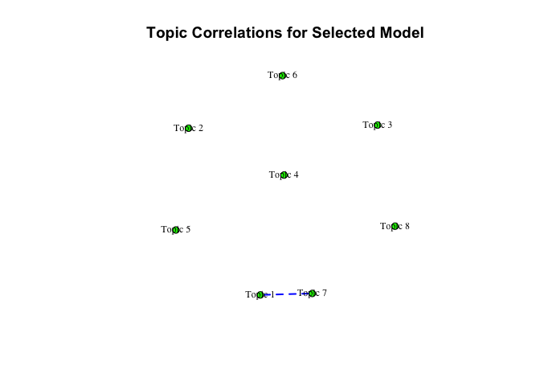

- Fit_prevalence:

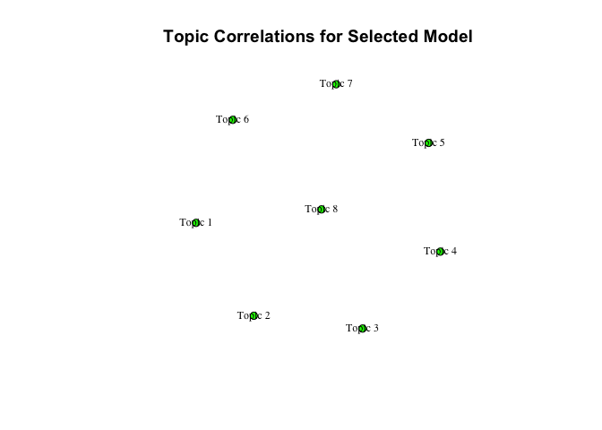

- Fit_content:

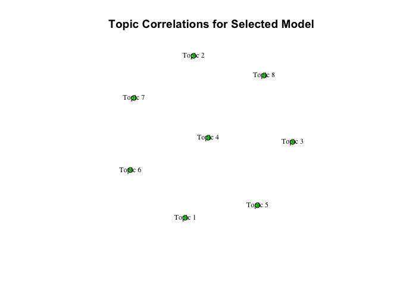

Apart from topic 7 and 1 in the Fit0_selectedmodel, there seems to be no correlation between the topics.

A higher grade of correlation between topics could indicate that the STM model is not well-suited for this data. In that case, a CTM could be more appropriate.

### Top topics’ words

#### Top 7 words per topic

- Fit0_selectedmodel:

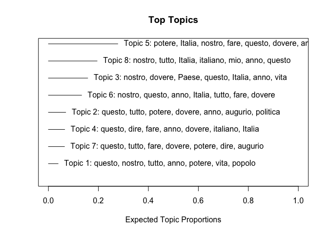

- Fit_prevalence:

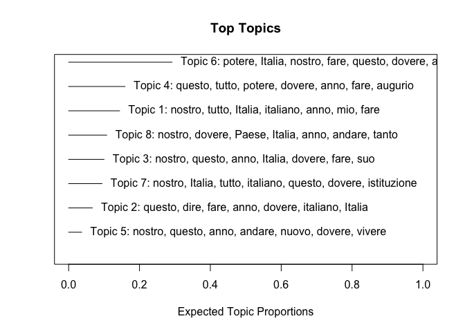

- Fit_content:

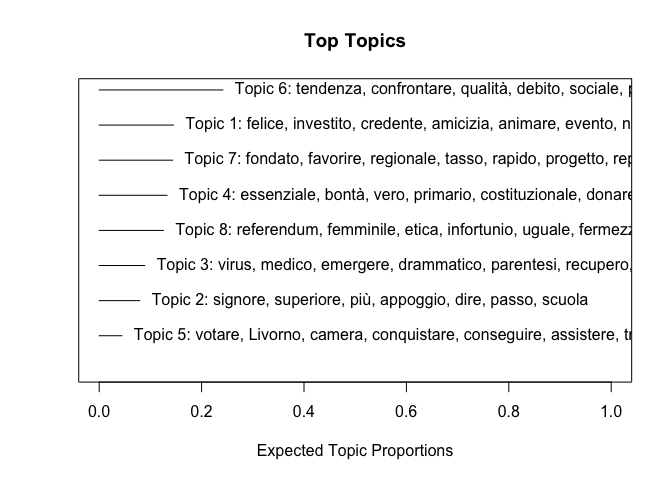

We can see how Fit_content differs from the other models, with more distinct words in the modeled topics. For this model, we can also explore the effect of year for each topic:

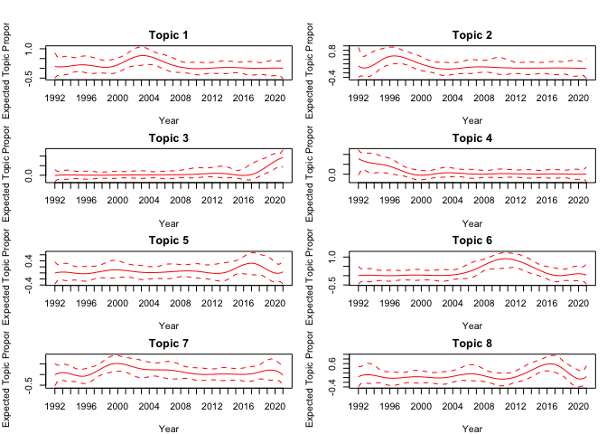

#### Top words with labelTopics function

Another way to explore the words associated with each topic, is using the `labelTopics` function. This function provides: - Words with the `highest probability` of appearing in each topic. - `FREX` words, which balance frequency and exclusivity. - `Lift` and `Score` metrics, which prioritize words that are less common across other topics.

These last three metrics are particularly useful for identifying the most representative words for each topic. Relying solely on `highest probability` words may be less informative, as many frequently used terms tend to appear repeatedly across the texts, as seen in the plot of common words used by presidents.

- Fit0_selectedmodel:

```
## Topic 1 Top Words:
##       Highest Prob: questo, nostro, tutto, anno, potere, vita, popolo
##       FREX: eroismo, donare, ripresa, ottimismo, consumare, male, Israele
##       Lift: pessimista, ottimismo, invincibile, inefficiente, consumare, ammirato, eccezionale
##       Score: ottimismo, consumare, eroismo, eccezionale, male, pessimista, sofferente
## Topic 2 Top Words:
##       Highest Prob: questo, tutto, potere, dovere, anno, augurio, politica
##       FREX: dipendere, verità, quanto, partito, giudizio, vostro, risorgere
##       Lift: confusione, oggettivo, sconcerto, universale, intrecciare, controllo, stampa
##       Score: quanto, risorgere, confusione, giudizio, penale, male, parere
## Topic 3 Top Words:
##       Highest Prob: nostro, dovere, Paese, questo, Italia, anno, vita
##       FREX: concittadino, alcuno, luogo, riconoscenza, positivo, sicurezza, rivolgere
##       Lift: ampliare, carenza, civico, femminile, periferia, risentimento, versare
##       Score: concittadino, luogo, territorio, rivolgere, significare, evasione, civico
## Topic 4 Top Words:
##       Highest Prob: questo, dire, fare, anno, dovere, italiano, Italia
##       FREX: dire, parlare, qualche, scuola, persona, ricordare, capo
##       Lift: commozione, devozione, errare, fedele, girare, grazia, grido
##       Score: grazia, grido, speculare, ministro, parere, quanto, pena
## Topic 5 Top Words:
##       Highest Prob: potere, Italia, nostro, fare, questo, dovere, anno
##       FREX: critico, crisi, riforma, sviluppo, restare, economia, sociale
##       Lift: accumulare, analisi, ancorare, asprezza, assillo, attribuire, attuazione
##       Score: critico, economia, restare, crescere, istituzionale, crescita, qualità
## Topic 6 Top Words:
##       Highest Prob: nostro, questo, anno, Italia, tutto, fare, dovere
##       FREX: pandemia, virus, vaccino, caro, prevalere, disastro, vaccinare
##       Lift: avanguardia, buio, centenario, disegnare, estate, intorno, lutto
##       Score: pandemia, concittadino, virus, vaccino, vaccinare, disastro, emergere
## Topic 7 Top Words:
##       Highest Prob: questo, tutto, fare, dovere, potere, dire, augurio
##       FREX: grazie, costituzionale, pagina, magistrato, cosa, voltare, presidente
##       Lift: esaminare, meditazione, sparare, colmo, orante, peggio, sciogliere
##       Score: voltare, pagina, parere, magistrato, legittimo, silenzio, bussare
## Topic 8 Top Words:
##       Highest Prob: nostro, tutto, Italia, italiano, mio, anno, questo
##       FREX: identità, secolo, Unione_Europea, spirito, stesso, istituzione, città
##       Lift: accelerazione, comunale, concordia, creazione, diffusione, moglie, Resistenza
##       Score: secolo, istituzione, città, realizzare, identità, Risorgimento, comunale
```

- Fit_prevalence:

```
## Topic 1 Top Words:
##       Highest Prob: nostro, tutto, Italia, italiano, anno, mio, fare
##       FREX: nazione, cuore, terra, sogno, amore, patria, ideale
##       Lift: avanguardia, inno, Mameli, tricolore, amato, aria, contemporaneo
##       Score: tricolore, inno, nazione, amato, Risorgimento, Mameli, mente
## Topic 2 Top Words:
##       Highest Prob: questo, dire, fare, anno, dovere, italiano, Italia
##       FREX: dire, qualche, capo, parlare, gente, quanto, ministro
##       Lift: commozione, fedele, grazia, grido, Islanda, speculare, devozione
##       Score: grazia, grido, speculare, parere, capo, ministro, gente
## Topic 3 Top Words:
##       Highest Prob: nostro, questo, anno, Italia, dovere, fare, suo
##       FREX: pandemia, virus, vaccino, ruolo, vaccinare, scienza, trasmettere
##       Lift: intorno, precauzione, vaccinare, collega, consueto, fornire, imprevedibile
##       Score: vaccinare, pandemia, concittadino, virus, vaccino, intorno, precauzione
## Topic 4 Top Words:
##       Highest Prob: questo, tutto, potere, dovere, anno, fare, augurio
##       FREX: volontà, pagina, quanto, voltare, costituzionale, partito, verità
##       Lift: amministratore, arrendere, data, distinto, eccezionale, esaminare, genitore
##       Score: pagina, intriso, parere, voltare, male, quanto, spegnere
## Topic 5 Top Words:
##       Highest Prob: nostro, questo, anno, andare, nuovo, dovere, vivere
##       FREX: votare, era, camera, aprire, elettorale, costituire, voto
##       Lift: era, Livorno, festeggiare, votare, assistere, trappola, camera
##       Score: era, concittadino, votare, Livorno, riguardo, informazione, festeggiare
## Topic 6 Top Words:
##       Highest Prob: potere, Italia, nostro, fare, questo, dovere, anno
##       FREX: critico, riforma, crisi, generale, sforzo, economia, pubblico
##       Lift: corrente, malessere, prospettare, travaglio, abbandonare, abnorme, accumulare
##       Score: critico, sconvolgente, istituzionale, crescita, collettivo, restare, prova
## Topic 7 Top Words:
##       Highest Prob: nostro, Italia, tutto, italiano, questo, dovere, istituzione
##       FREX: vostro, secolo, assicurare, stato, istituzione, Unione_Europea, benessere
##       Lift: accelerazione, alba, conferenza, mantenimento, godere, compagnia, diffusione
##       Score: accelerazione, secolo, mantenimento, istituzione, diffusa, slancio, comunale
## Topic 8 Top Words:
##       Highest Prob: nostro, dovere, Paese, Italia, anno, andare, tanto
##       FREX: alcuno, riconoscenza, significare, ascoltare, numeroso, rappresentare, positivo
##       Lift: atleta, carenza, discriminazione, migrante, pacifico, Parigi, periferia
##       Score: referendum, concittadino, evasione, odio, periferia, carenza, significare
```

### Topic proportions per president

- Fit0_selectedmodel:

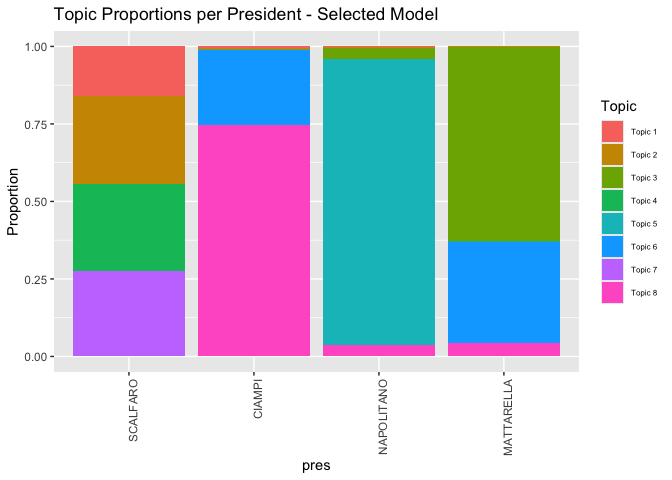

- Fit_prevalence:

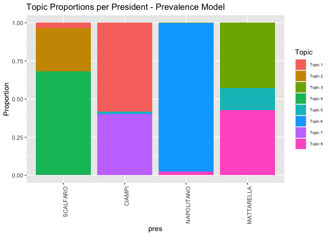

- Fit_content:

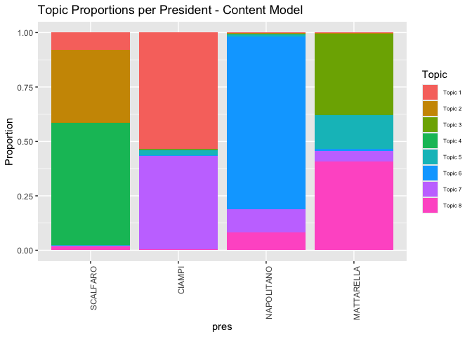

### Perspectives plot

The last thing we can do is examine the perspective plots. These plots illustrate how various words are linked to specific topics for two presidents. The size of the words represents their significance within the topic, while their color and placement reflect their connection to each president.

For example, we can compare the perspectives of SCALFARO and CIAMPI for the content model in the 3rd topic:

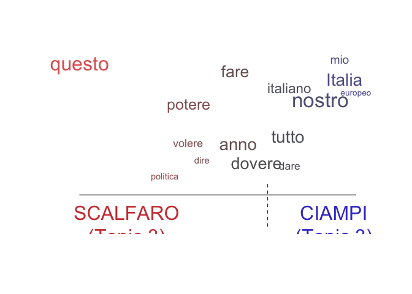

```r
plot(Fit_content, type = "perspectives", topics = 3, covarlevels = c("SCALFARO" ,"CIAMPI"))
```

This plot reveals how Italy’s adoption of the Euro on January 1, 2002, may be reflected in the topic distribution for CIAMPI (the word ‘europeo’) but is not prominently highlighted for SCALFARO.